# HIV Infection Analysis Dimension Reduction of DMSO, SAHA and PMA Datasets

Oscar Miguel, Pepe Merino, Jordi Resina

2026-06-01

# Libraries

```r
library(ggplot2)
library(dplyr)
library(tidyr)
library(reshape2)
library(gridExtra)
library(RColorBrewer)
library(ggrepel)
library(Rtsne)
library(patchwork)
library(knitr)
library(umap)
library(cluster)
library(plotly)
```

# Introduction

This transcriptomic study investigates apoptosis mechanisms in HIV infection using uninfected Jurkat and latently infected J-Lat T-cell lines.

Exploratory dimension reduction via PCA or UMAP will be used to visualize sample clustering and ensure data quality. The pipeline contains no outliers, setting a reliable baseline to isolate true biological variance across the conditions. Ultimately, this setup enables targeted differential expression analysis to track transcriptomic shifts governing apoptotic pathways. Interactive volcano plots, boxplots, and tabsets will be deployed to dynamically interpret the downstream genomic results.

**Experimental design:**

```r
design_summary <- data.frame(
  Factor = c("Cell line", "Treatment", "Replicates"),
  Levels = c("Jurkat T cells (HIV-negative), J-Lat2 (latent HIV infection)",
             "DMSO (control), SAHA (HDAC inhibitor), PMA",
             "3 independent experiments (rep1, rep2, rep3)")
)
kable(design_summary, caption = "Table 1: Summary of the Experimental Design")
```

Table 1: Summary of the Experimental Design

| Factor | Levels |
| --- | --- |
| Cell line | Jurkat T cells (HIV-negative), J-Lat2 (latent HIV infection) |
| Treatment | DMSO (control), SAHA (HDAC inhibitor), PMA |
| Replicates | 3 independent experiments (rep1, rep2, rep3) |

The dataset was provided as a raw counts matrix (genes x samples) and an associated sample sheet. Batch effects may be present across replicates and normalization will be performed accordingly.

# Assembling dataset

## Question 1 – Load, Adapt the Data and Create Metadata

## 1.1 Load the counts matrix

The counts file stores genes as rows and samples as columns.  
The sample sheet uses `;` as delimiter and contains three metadata variables: `cell_type`, `treatment`, and `replicate`.

```r
counts_raw <- read.csv("counts.csv", row.names = 1, check.names = FALSE)

sample_sheet <- read.csv("sample_sheet.csv", sep = ";", row.names = 1)

cat("Counts matrix dimensions (genes × samples):", dim(counts_raw), "\n")
```

```
## Counts matrix dimensions (genes × samples): 22798 271
```

```r
cat("Sample sheet dimensions:", dim(sample_sheet), "\n")
```

```
## Sample sheet dimensions: 271 3
```

## 1.2 Verify dimensions and sample order

We check that every column name in the counts matrix appears exactly once in the sample sheet rows, and that their order matches.

```r
all_present <- all(colnames(counts_raw) %in% rownames(sample_sheet))
cat("All count columns present in sample sheet:", all_present, "\n")
```

```
## All count columns present in sample sheet: TRUE
```

```r
sample_sheet <- sample_sheet[colnames(counts_raw), ]

order_ok <- all(colnames(counts_raw) == rownames(sample_sheet))
cat("Sample order matches between counts and metadata:", order_ok, "\n")
```

```
## Sample order matches between counts and metadata: TRUE
```

## 1.3 Adapt the data – transpose to samples × genes

**Technical Design Note:** Dimensionality reduction algorithms (PCA, t-SNE, and UMAP) strictly expect the data matrix to be structured with rows representing observations (samples) and columns representing features or variables (genes).

```r
counts_t <- as.data.frame(t(counts_raw))   # samples × genes

cat("Transposed matrix dimensions (samples × genes):", dim(counts_t), "\n")
```

```
## Transposed matrix dimensions (samples × genes): 271 22798
```

## 1.4 Metadata dataframe

```r
metadata <- sample_sheet

metadata$group <- paste(metadata$cell_type, metadata$treatment, sep = "_")

kable(head(metadata, 10), caption = "First 10 rows of the metadata dataframe")
```

First 10 rows of the metadata dataframe

|  | cell_type | treatment | replicate | group |
| --- | --- | --- | --- | --- |
| P2769_N701.S502 | Jurkat | DMSO | rep1 | Jurkat_DMSO |
| P2769_N701.S503 | Jurkat | SAHA | rep1 | Jurkat_SAHA |
| P2769_N701.S505 | Jurkat | PMA | rep1 | Jurkat_PMA |
| P2769_N701.S506 | J-LatA2 | DMSO | rep1 | J-LatA2_DMSO |
| P2769_N701.S508 | J-LatA2 | SAHA | rep1 | J-LatA2_SAHA |
| P2769_N701.S510 | J-LatA2 | PMA | rep1 | J-LatA2_PMA |
| P2769_N701.S511 | J-LatA2 | PMA | rep1 | J-LatA2_PMA |
| P2769_N702.S502 | Jurkat | DMSO | rep1 | Jurkat_DMSO |
| P2769_N702.S503 | Jurkat | SAHA | rep1 | Jurkat_SAHA |
| P2769_N702.S505 | Jurkat | PMA | rep1 | Jurkat_PMA |

```r
design_tbl <- metadata %>%
  group_by(cell_type, treatment, replicate) %>%
  summarise(n_samples = n(), .groups = "drop")

kable(design_tbl, caption = "Experimental design: number of samples per group")
```

Experimental design: number of samples per group

| cell_type | treatment | replicate | n_samples |
| --- | --- | --- | --- |
| J-LatA2 | DMSO | rep1 | 12 |
| J-LatA2 | DMSO | rep2 | 12 |
| J-LatA2 | DMSO | rep3 | 11 |
| J-LatA2 | PMA | rep1 | 27 |
| J-LatA2 | PMA | rep2 | 27 |
| J-LatA2 | PMA | rep3 | 26 |
| J-LatA2 | SAHA | rep1 | 21 |
| J-LatA2 | SAHA | rep2 | 23 |
| J-LatA2 | SAHA | rep3 | 22 |
| Jurkat | DMSO | rep1 | 6 |
| Jurkat | DMSO | rep2 | 6 |
| Jurkat | DMSO | rep3 | 6 |
| Jurkat | PMA | rep1 | 12 |
| Jurkat | PMA | rep2 | 12 |
| Jurkat | PMA | rep3 | 12 |
| Jurkat | SAHA | rep1 | 12 |
| Jurkat | SAHA | rep2 | 12 |
| Jurkat | SAHA | rep3 | 12 |

Interpretation: Sample size variation across replicates introduces a slight imbalance to the experimental design. Consequently, the replicate variable will serve to detect potential batch effects in the down-stream PCA and t-SNE dimension reductions.

# PCA

## Question 2 – PCA Representation

### 2.1 Helper function for PCA plotting

We define a reusable function to avoid code duplication.

```r
run_pca <- function(mat, scale. = FALSE, center = TRUE) {
  prcomp(mat, scale. = scale., center = center)
}

pca_var_explained <- function(pca_obj) {
  var_exp <- pca_obj$sdev^2 / sum(pca_obj$sdev^2) * 100
  data.frame(
    PC       = seq_along(var_exp),
    variance = var_exp
  )
}

pca_scores_df <- function(pca_obj, metadata, pc1 = 1, pc2 = 2) {
  df <- as.data.frame(pca_obj$x[, c(pc1, pc2)])
  colnames(df) <- c("PC1", "PC2")
  cbind(df, metadata)
}

plot_scree <- function(var_df, n = 15, title = "Scree plot") {
  ggplot(var_df[1:n, ], aes(x = PC, y = variance)) +
    geom_col(fill = "lightblue2", colour = "white") +
    geom_line(colour = "darkred", size = 0.8) +
    geom_point(colour = "darkred", size = 2) +
    labs(title = title,
         x = "Principal Component", y = "Variance explained (%)")
}

plot_pca <- function(scores_df, colour_var, shape_var = NULL,
                     title = "PCA", xlab = "PC1", ylab = "PC2",
                     palette = NULL) {
  p <- ggplot(scores_df, aes_string(x = "PC1", y = "PC2",
                                    colour = colour_var,
                                    shape  = shape_var)) +
    geom_point(size = 3, alpha = 0.85) +
    labs(title = title, x = xlab, y = ylab) +
    theme(legend.position = "right")
  if (!is.null(palette)) p <- p + scale_colour_manual(values = palette)
  p
}
```

### 2.2 Raw (non-scaled, non-normalised) PCA

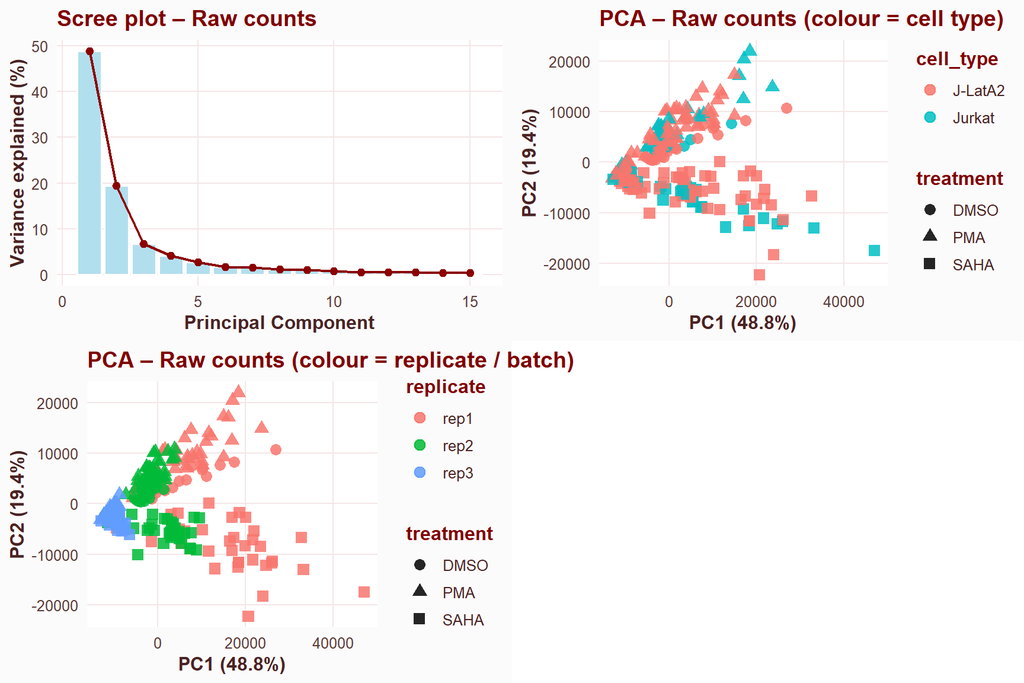

```r
pca_raw <- run_pca(counts_t, scale. = FALSE, center = TRUE)

var_raw  <- pca_var_explained(pca_raw)
sc_raw   <- pca_scores_df(pca_raw, metadata)

xlab_raw <- paste0("PC1 (", round(var_raw$variance[1], 1), "%)")
ylab_raw <- paste0("PC2 (", round(var_raw$variance[2], 1), "%)")

p1 <- plot_scree(var_raw, title = "Scree plot – Raw counts")

p2 <- plot_pca(sc_raw, colour_var = "cell_type", shape_var = "treatment",
               title = "PCA – Raw counts (colour = cell type)",
               xlab = xlab_raw, ylab = ylab_raw)

p3 <- plot_pca(sc_raw, colour_var = "replicate", shape_var = "treatment",
               title = "PCA – Raw counts (colour = replicate / batch)",
               xlab = xlab_raw, ylab = ylab_raw)
grid.arrange(p1, p2, p3, ncol = 2)
```

**Interpretation – Raw PCA:**

As expected, the PCA on raw counts is heavily dominated by differences in library size rather than biological signal, with highly expressed genes distorting the projection. Grouping by replicate already reveals a noticeable batch effect, as samples from the same condition but different batches separate along PC2.

If we try to interpret this biologically, it would mean that our cells are suffering a massive global amplification of transcription, or that the Jurkat and J-Lat2 lines are fundamentally changing their core identity between replicate 1, 2, and 3. But obviously, this is impossible because they are biological clones and we standardized the RNA input before the library preparation. What we are really seeing here is just a technical artifact: the massive differences in library size depend on things like pipetting or sequencing depth, and the separation in PC2 is a clear batch effect caused by doing the experiment on different days or with different media, not real biology.

### 2.3 Total expression normalisation

To reduce library-size bias we perform a total expression normalization as requested.

```r
genes_total <- colSums(counts_t)
counts_clean <- counts_t[, genes_total > 0]

sample_totals <- rowSums(counts_clean)

counts_norm_raw <- counts_clean / sample_totals

cat("Sample totals – summary:\n"); print(summary(sample_totals))
```

```
## Sample totals – summary:
```

```
##    Min. 1st Qu.  Median    Mean 3rd Qu.    Max.
##   29184  133784  374879  344827  464402 1026101
```

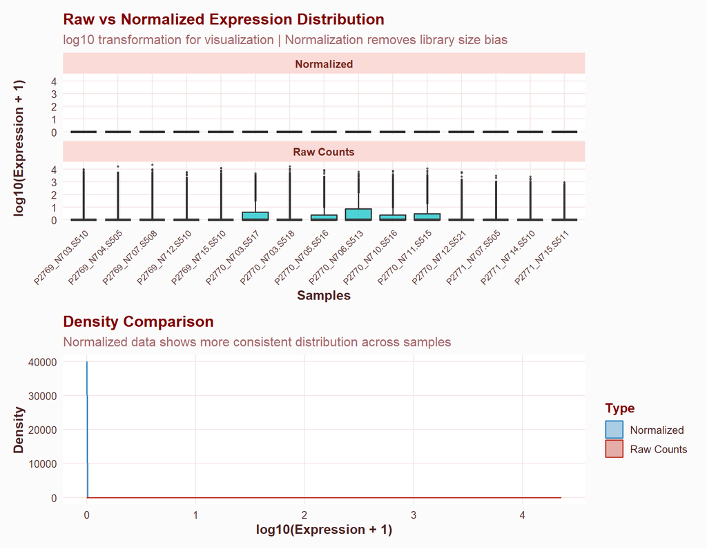

```r
set.seed(42)
sample_idx <- sample(1:nrow(counts_t), 15)

df_raw_plot <- data.frame(
  Sample = rep(rownames(counts_t)[sample_idx], each = ncol(counts_t)),
  Expression = as.vector(t(counts_t[sample_idx, ])),
  Type = "Raw Counts"
)

df_norm_plot <- data.frame(
  Sample = rep(rownames(counts_norm_raw)[sample_idx], each = ncol(counts_norm_raw)),
  Expression = as.vector(t(counts_norm_raw[sample_idx, ])),
  Type = "Normalized"
)

df_combined <- rbind(df_raw_plot, df_norm_plot)

p_boxplot <- ggplot(df_combined, aes(x = Sample, y = log10(Expression + 1), fill = Type)) +
  geom_boxplot(alpha = 0.7, outlier.size = 0.5) +
  facet_wrap(~Type, nrow = 2) +
  labs(title = "Raw vs Normalized Expression Distribution",
       subtitle = "log10 transformation for visualization | Normalization removes library size bias",
       x = "Samples", y = "log10(Expression + 1)") +
  theme_hospital_bio() +
  theme(axis.text.x = element_text(angle = 45, hjust = 1, size = 8), legend.position = "none")

p_density <- ggplot(df_combined, aes(x = log10(Expression + 1), colour = Type, fill = Type)) +
  geom_density(alpha = 0.4) +
  labs(title = "Density Comparison",
       subtitle = "Normalized data shows more consistent distribution across samples",
       x = "log10(Expression + 1)", y = "Density") +
  scale_colour_manual(values = c("Raw Counts" = "#C0392B", "Normalized" = "#2E86C1")) +
  scale_fill_manual(values = c("Raw Counts" = "#C0392B", "Normalized" = "#2E86C1")) +
  theme_hospital_bio()

p_boxplot / p_density
```

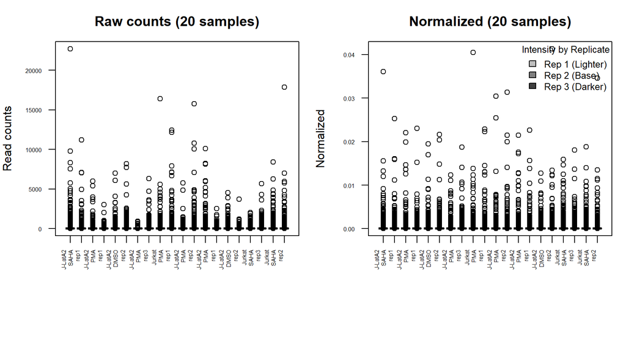

```r
set.seed(42)
idx <- sample(nrow(counts_t), 20)

labels_sub <- paste(metadata$cell_type[idx], metadata$treatment[idx],
                    metadata$replicate[idx], sep = "\n")

base_groups <- paste(metadata$cell_type[idx], metadata$treatment[idx], sep = "_")
base_colors <- group_colours[base_groups]

get_solid_intensity <- function(color, rep) {
  rep_num <- as.numeric(gsub("[^0-9]", "", as.character(rep)))

  if (is.na(rep_num) || rep_num == 2) {
    return(color)
  } else if (rep_num == 1) {
    return(colorRampPalette(c("white", color))(5)[3])
  } else {
    return(colorRampPalette(c("black", color))(5)[3])
  }
}

final_colors <- mapply(get_solid_intensity, base_colors, metadata$replicate[idx])

par(mfrow = c(1, 2), mar = c(8, 4, 3, 1))

boxplot(t(counts_t[idx, ]),
        las = 2, cex.axis = 0.5,
        col  = final_colors,
        main = "Raw counts (20 samples)",
        ylab = "Read counts", names = labels_sub)

boxplot(t(counts_norm_raw[idx, ]),
        las = 2, cex.axis = 0.5,
        col  = final_colors,
        main = "Normalized (20 samples)",
        ylab = "Normalized", names = labels_sub)

legend_colors <- c(
  colorRampPalette(c("white", "gray50"))(5)[3],
  "gray50",
  colorRampPalette(c("black", "gray50"))(5)[3]
)

legend("topright", legend = c("Rep 1 (Lighter)", "Rep 2 (Base)", "Rep 3 (Darker)"),
       fill = legend_colors, bty = "n", cex = 0.8, title = "Intensity by Replicate")
```

```r
par(mfrow = c(1, 1))
```

### 2.4 Scaled PCA (z-score across genes)

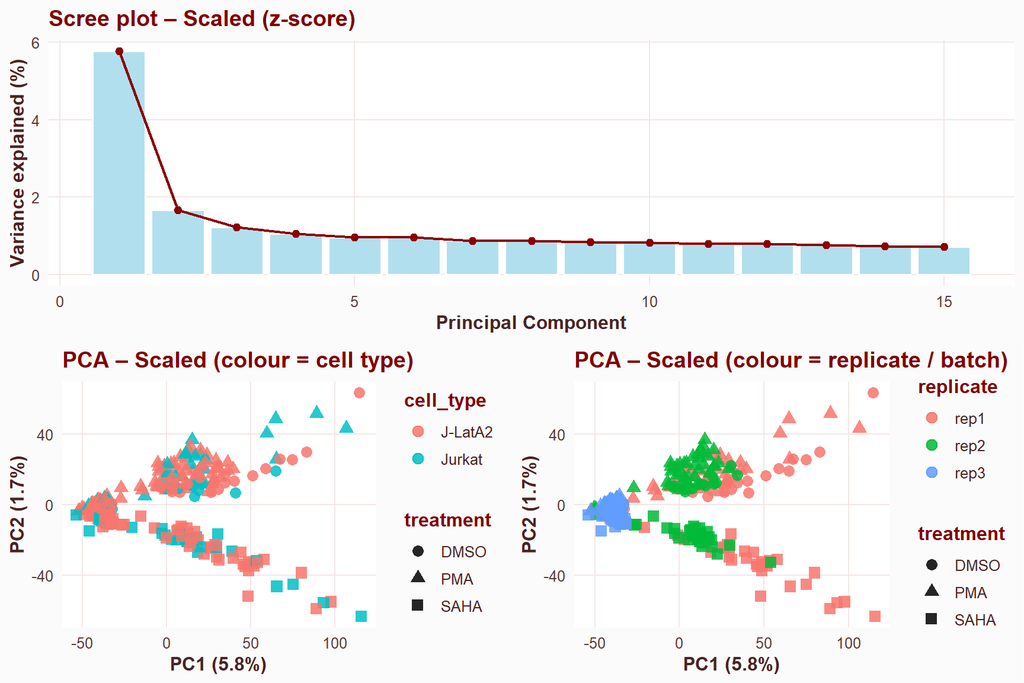

```r
pca_scaled <- run_pca(counts_t, scale. = TRUE, center = TRUE)

var_scaled  <- pca_var_explained(pca_scaled)
sc_scaled   <- pca_scores_df(pca_scaled, metadata)

xlab_sc <- paste0("PC1 (", round(var_scaled$variance[1], 1), "%)")
ylab_sc <- paste0("PC2 (", round(var_scaled$variance[2], 1), "%)")

p4 <- plot_scree(var_scaled, title = "Scree plot – Scaled (z-score)")

p5 <- plot_pca(sc_scaled, colour_var = "cell_type", shape_var = "treatment",
               title = "PCA – Scaled (colour = cell type)",
               xlab = xlab_sc, ylab = ylab_sc)

p6 <- plot_pca(sc_scaled, colour_var = "replicate", shape_var = "treatment",
               title = "PCA – Scaled (colour = replicate / batch)",
               xlab = xlab_sc, ylab = ylab_sc)

grid.arrange(p4, p5, p6, layout_matrix = rbind(c(1,1), c(2,3)))
```

### 2.5 PCA on Normalized normalised data

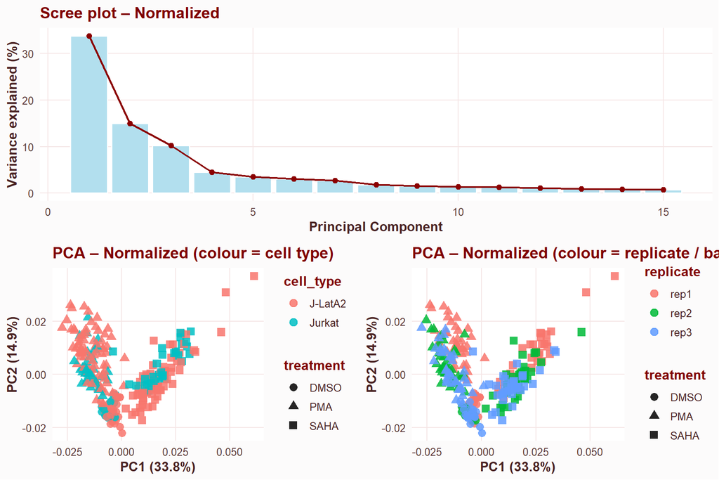

```r
pca_norm <- run_pca(counts_norm_raw, scale. = FALSE, center = TRUE)

var_norm  <- pca_var_explained(pca_norm)
sc_norm   <- pca_scores_df(pca_norm, metadata)

xlab_norm <- paste0("PC1 (", round(var_norm$variance[1], 1), "%)")
ylab_norm <- paste0("PC2 (", round(var_norm$variance[2], 1), "%)")

p7 <- plot_scree(var_norm, title = "Scree plot – Normalized")

p8 <- plot_pca(sc_norm, colour_var = "cell_type", shape_var = "treatment",
               title = "PCA – Normalized (colour = cell type)",
               xlab = xlab_norm, ylab = ylab_norm)

p9 <- plot_pca(sc_norm, colour_var = "replicate", shape_var = "treatment",
               title = "PCA – Normalized (colour = replicate / batch)",
               xlab = xlab_norm, ylab = ylab_norm)

grid.arrange(p7, p8, p9, layout_matrix = rbind(c(1,1), c(2,3)))
```

### 2.6 Variance explained – comparison table

```r
var_compare <- data.frame(
  PC          = 1:10,
  Raw         = round(var_raw$variance[1:10], 2),
  Scaled      = round(var_scaled$variance[1:10], 2),
  Norm        = round(var_norm$variance[1:10], 2)
)
kable(var_compare,
      caption = "% variance explained by PC1–10 under different preprocessing")
```

% variance explained by PC1–10 under different preprocessing

| PC | Raw | Scaled | Norm |
| --- | --- | --- | --- |
| 1 | 48.76 | 5.76 | 33.78 |
| 2 | 19.41 | 1.67 | 14.95 |
| 3 | 6.78 | 1.22 | 10.23 |
| 4 | 4.18 | 1.06 | 4.56 |
| 5 | 2.71 | 0.97 | 3.50 |
| 6 | 1.79 | 0.97 | 3.10 |
| 7 | 1.59 | 0.88 | 2.73 |
| 8 | 1.22 | 0.87 | 1.80 |
| 9 | 1.05 | 0.85 | 1.60 |
| 10 | 0.77 | 0.83 | 1.39 |

1. Raw PCA: When we applied PCA directly to the raw count matrix, we immediately observed a severe structural bias: the first Principal Component (PC1) captured an abnormally high 48.76% of the total variance. In the context of transcriptomic data, such a high figure is a clear red flag indicating that a single source of variation is completely dominant. In our case, this source is the library size (sequencing depth). Because some samples were sequenced deeper than others, this principal component captures a purely technical artifact, completely masking the true biological differences in gene expression that we aim to study.
2. Scaled PCA (Z-score) To attempt to correct this technical bias, we standardized the data using z-score scaling. However, the resulting PCA showed a variance distribution that was far too uniform, with PC1 dropping drastically to just 5.76%. While scaling forces every gene to have a mean of zero and a variance of one, this approach proved counterproductive for our dataset. By assigning exactly the same mathematical weight to every single gene, we effectively amplified the background noise. Genes with almost null expression—where variations are purely stochastic and uninformative—gained the same influence as highly expressed, biologically relevant genes. This overwhelming wave of homogeneous noise completely blurred the underlying structure of the data, preventing any principal component from defining clear biological clusters.
3. Normalized PCA Finally, when we applied a proper normalization method, we obtained a much more balanced and coherent variance distribution: PC1 accounted for 33.78% and PC2 for 14.95%. This preprocessing step allowed us to successfully eliminate the bias introduced by library size without suppressing the inherent variability of highly expressed genes. By doing so, we managed to clean up the technical artifacts while retaining and emphasizing the true biological expression differences between the genes.
4. Compartison Raw vs Normalized Looking and the plots and their interpretation showed to us the absolute necessity of normalization. The Raw PCA is entirely hijacked by sequencing depth artifacts, making it fundamentally flawed and practically useless for authentic biological interpretation, as it reflects how the data was collected rather than what the data actually means. Conversely, the Normalized PCA strikes the essential balance: it effectively zeroes out the technical noise of library size while fully preserving and highlighting the critical biological variance. Therefore, we can truly conclude that the normalized dimensional space is the only one that provides a reliable, accurate representation of our samples’ true expression profiles, making it the definitive framework we will utilize for all downstream biological analyses.

### 2.7 Batch effect assessment

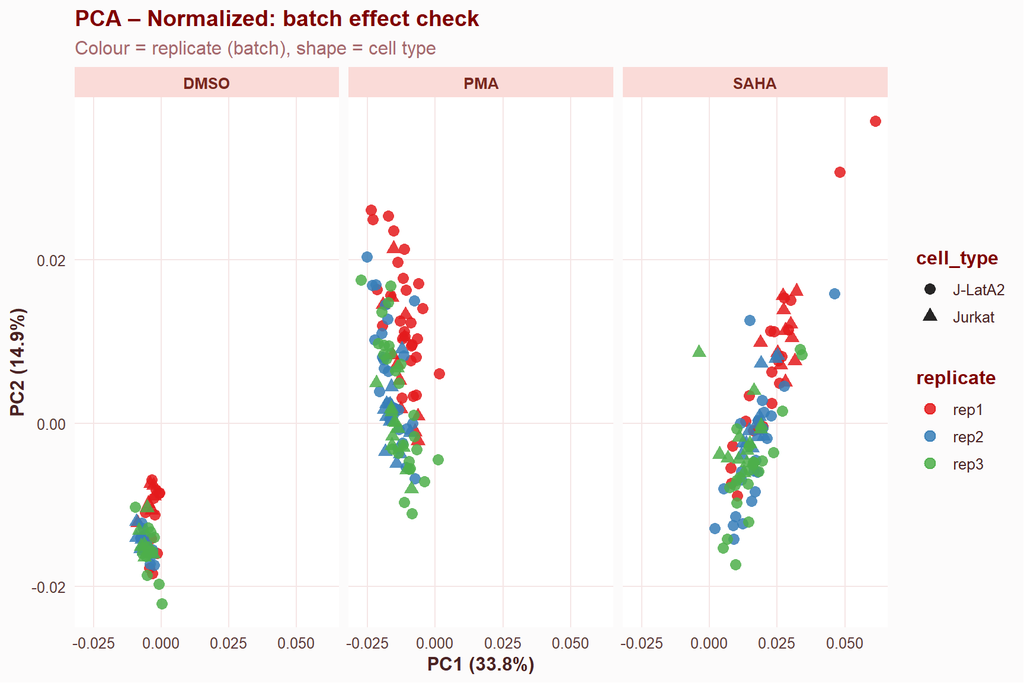

```r
ggplot(sc_norm, aes(x = PC1, y = PC2,
                    colour = replicate, shape = cell_type)) +
  geom_point(size = 3, alpha = 0.85) +
  facet_wrap(~treatment) +
  labs(title = "PCA – Normalized: batch effect check",
       subtitle = "Colour = replicate (batch), shape = cell type",
       x = xlab_norm, y = ylab_norm) +
  scale_colour_brewer(palette = "Set1")
```

**Interpretation – Batch effects:**

Biologically, the massive changes in gene expression and strong clustering we observe are overwhelmingly driven by the latency-reversing treatments (SAHA and especially PMA) compared to the DMSO control. It is crucial to note that uninfected Jurkat cells and J-LatA2 cells (which harbor latent HIV) share a nearly identical transcriptomic profile in their basal state. Therefore, the primary variance is not driven by cell type before stimulation, but by the massive transcriptional shock given by the drugs.

The separation observed along PC2 represents technical noise—likely batch effects from minor differences in lab conditions, handling, or reagents on the specific day the replicates were processed. By identifying and eventually correcting this noise, we ensure that our downstream analysis only measures true biological changes, preventing false statistical results.

Visualizing the normalized data by replicate confirmed to us that it had a mild batch effect, samples from replicate 1 tend to cluster separately from replicates 2 and 3. However, the biological signal (treatment) remains the absolute dominant driver of variance. And based on the initial dataset quality control guidelines, no outliers require removal.

### 2.8 PC1/PC2 correlation with metadata variables

Here we did this Kruskal-Wallis test, because as we only have n=3 replicates, we can’t assume normality, making a non-parametric test like Kruskal-Wallis much safer than an ANOVA. Also the design is unbalanced, and Kruskal-Wallis handles unequal group sizes and variances better, avoiding potential false positives. It works for both 2 groups (cell type) and 3 groups (treatment), so we could use the same statistical test for every variable. This allowed us to wrap everything in a for loop, making the code much cleaner, more efficient, and easier to automate.

```r
covariables <- c("cell_type", "treatment", "replicate")

pc_pvals <- data.frame(
  PC1_p = sapply(covariables, function(x) kruskal.test(sc_norm$PC1 ~ as.factor(sc_norm[[x]]))$p.value),
  PC2_p = sapply(covariables, function(x) kruskal.test(sc_norm$PC2 ~ as.factor(sc_norm[[x]]))$p.value)
)

print(round(pc_pvals, 4))
```

```
##            PC1_p  PC2_p
## cell_type 0.7633 0.9528
## treatment 0.0000 0.0000
## replicate 0.0770 0.0000
```

#### Alternatives

##### Method 1: Boxplots

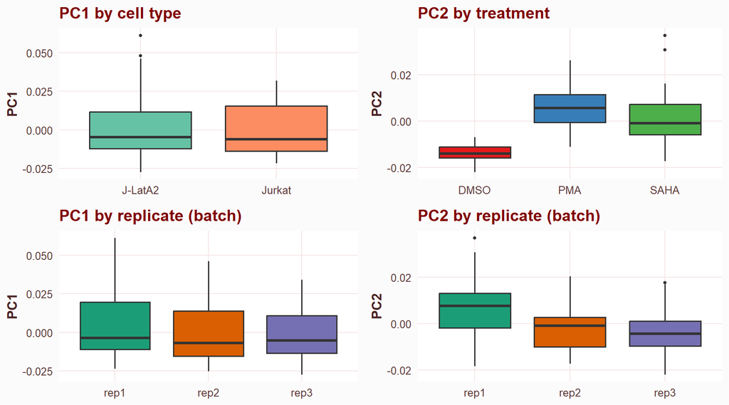

```r
b1 <- ggplot(sc_norm, aes(x = cell_type, y = PC1, fill = cell_type)) +
  geom_boxplot(outlier.size = 1) +
  scale_fill_brewer(palette = "Set2") +
  labs(title = "PC1 by cell type", x = NULL) +
  theme(legend.position = "none")

b2 <- ggplot(sc_norm, aes(x = treatment, y = PC2, fill = treatment)) +
  geom_boxplot(outlier.size = 1) +
  scale_fill_brewer(palette = "Set1") +
  labs(title = "PC2 by treatment", x = NULL) +
  theme(legend.position = "none")

b3 <- ggplot(sc_norm, aes(x = replicate, y = PC1, fill = replicate)) +
  geom_boxplot(outlier.size = 1) +
  scale_fill_brewer(palette = "Dark2") +
  labs(title = "PC1 by replicate (batch)", x = NULL) +
  theme(legend.position = "none")

b4 <- ggplot(sc_norm, aes(x = replicate, y = PC2, fill = replicate)) +
  geom_boxplot(outlier.size = 1) +
  scale_fill_brewer(palette = "Dark2") +
  labs(title = "PC2 by replicate (batch)", x = NULL) +
  theme(legend.position = "none")

grid.arrange(b1, b2, b3, b4, nrow = 2)
```

**Interpretation – Boxplot:**

These boxplots visually confirm our statistical findings regarding the primary drivers of variance in our normalized dataset. We can clearly see that baseline cell type barely influences PC1, with J-LatA2 and Jurkat showing nearly identical and overlapping distributions. Conversely, the experimental treatments strongly drive the variance, distinctly separating the DMSO, PMA, and SAHA groups along PC2. Finally, the bottom panels isolate our technical batch effect: while replicates remain balanced across PC1, Replicate 1 shows a distinct upward shift along PC2, proving that this secondary axis captures a mixture of drug response and technical noise

##### Method 2: Interactive bar graph

```r
metadata_numeric <- sc_norm %>%
  mutate(
    cell_type_num = as.numeric(factor(cell_type)),
    treatment_num = as.numeric(factor(treatment)),
    replicate_num = as.numeric(factor(replicate))
  )

cor_pc1 <- c(
  Cell_Type = cor(metadata_numeric$PC1, metadata_numeric$cell_type_num),
  Treatment = cor(metadata_numeric$PC1, metadata_numeric$treatment_num),
  Replicate = cor(metadata_numeric$PC1, metadata_numeric$replicate_num)
)

cor_pc2 <- c(
  Cell_Type = cor(metadata_numeric$PC2, metadata_numeric$cell_type_num),
  Treatment = cor(metadata_numeric$PC2, metadata_numeric$treatment_num),
  Replicate = cor(metadata_numeric$PC2, metadata_numeric$replicate_num)
)

cor_df <- data.frame(
  PC = rep(c("PC1", "PC2"), each = 3),
  Variable = rep(c("Cell Type", "Treatment", "Replicate"), 2),
  Correlation = c(cor_pc1, cor_pc2)
)

plot_ly(cor_df,
        x = ~Variable,
        y = ~Correlation,
        color = ~PC,
        colors = c("#E41A1C", "#377EB8"),
        type = "bar",
        text = ~paste("PC:", PC, "<br>Variable:", Variable, "<br>R =", round(Correlation, 3)),
        hoverinfo = "text") %>%
  layout(title = "Correlation Strength between PCs and Metadata Variables",
         xaxis = list(title = "Metadata Variable"),
         yaxis = list(title = "Correlation Coefficient (R)", range = c(-1, 1)),
         barmode = "group",
         annotations = list(
           text = "Positive correlation = variable increases with PC | Negative = inverse relationship",
           x = 0.5, y = -0.15, xref = "paper", yref = "paper",
           showarrow = FALSE, font = list(size = 10)
         ),
         font = list(family = "Arial", size = 12, color = "#4A2323"),
         title = list(font = list(color = "#800000", face = "bold")),
         plot_bgcolor = "#FFFFFF",
         paper_bgcolor = "#FCFBFB")
```

[interactive chart not shown]

**Interpretation – PC correlation:**

PCA reduces our thousands of measured genes into components that capture the main sources of variation. Looking at how metadata variables associate with these PCs, the Kruskal-Wallis test shows that cell type alone doesn’t drive the global variance (p = 0.7633 for PC1; p = 0.9528 for PC2). This makes complete biological sense: J-LatA2 is simply a clonal derivative of Jurkat with a latent provirus. Before any drug is applied, their basal transcriptomes are virtually identical.

Instead, the experimental treatment is the absolute main driver of the data’s structure. It strongly correlates with both PC1 and PC2 (p = 0.0000 for both). This is clearly visible in the PCA plots: DMSO controls cluster tightly together, while the latency-reversing drugs (PMA and SAHA) push the expression profiles into completely different areas, confirming that the stimulation worked and fundamentally altered the cells’ transcription.

Because this batch effect takes up a huge chunk of the dataset’s variance, we must address and correct it before moving on to differential expression analysis. If we just ignored it and compared only the treatments, the uncorrected batch variance on PC2 would artificially inflate the statistical model’s noise. This would severely reduce our statistical power and increase the likelihood of missing truly differentially expressed genes.

### 2.9 Biological interpretation of the loadings

Here we can see what are the genes that drive the Principal Components the most

```r
loadings <- as.data.frame(pca_norm$rotation[, 1:2])
colnames(loadings) <- c("PC1", "PC2")

top_pc1 <- head(loadings[order(abs(loadings$PC1), decreasing=TRUE),], 10)
top_pc2 <- head(loadings[order(abs(loadings$PC2), decreasing=TRUE),], 10)

cat("Top genes driving PC1 (treatment axis):\n")
```

```
## Top genes driving PC1 (treatment axis):
```

```r
print(rownames(top_pc1))
```

```
##  [1] "ENSG00000251562.8"  "ENSG00000075624.14" "ENSG00000205542.10"
##  [4] "ENSG00000211751.9"  "ENSG00000064886.13" "ENSG00000111348.8"
##  [7] "ENSG00000132475.10" "ENSG00000184009.11" "ENSG00000182481.8"
## [10] "ENSG00000108518.7"
```

```r
cat("\nTop genes driving PC2 (batch/replicate axis):\n")
```

```
##
## Top genes driving PC2 (batch/replicate axis):
```

```r
print(rownames(top_pc2))
```

```
##  [1] "ENSG00000205542.10" "ENSG00000251562.8"  "ENSG00000075624.14"
##  [4] "ENSG00000280614.1"  "ENSG00000280800.1"  "ENSG00000281181.1"
##  [7] "ENSG00000211751.9"  "ENSG00000210082.2"  "ENSG00000164032.11"
## [10] "ENSG00000123416.15"
```

# t-SNE

## Question 3 – t-SNE Representation

### 3.1 Helper function for t-SNE

```r
run_tsne <- function(mat, perplexity = 30, max_iter = 1000,
                     check_duplicates = FALSE, pca = TRUE, seed = 42) {
  (seed)
  Rtsne(as.matrix(mat),
        perplexity       = perplexity,
        max_iter         = max_iter,
        check_duplicates = check_duplicates,
        pca              = pca,
        verbose          = FALSE)
}

plot_tsne <- function(tsne_obj, metadata, colour_var, shape_var = NULL,
                      title = "t-SNE", palette = NULL) {
  df <- data.frame(
    tSNE1 = tsne_obj$Y[, 1],
    tSNE2 = tsne_obj$Y[, 2],
    metadata
  )
  p <- ggplot(df, aes_string(x = "tSNE1", y = "tSNE2",
                              colour = colour_var,
                              shape  = shape_var)) +
    geom_point(size = 3, alpha = 0.85) +
    labs(title = title, x = "t-SNE 1", y = "t-SNE 2")
  if (!is.null(palette)) p <- p + scale_colour_manual(values = palette)
  p
}
```

### 3.2 Comparison: raw vs. normalised t-SNE

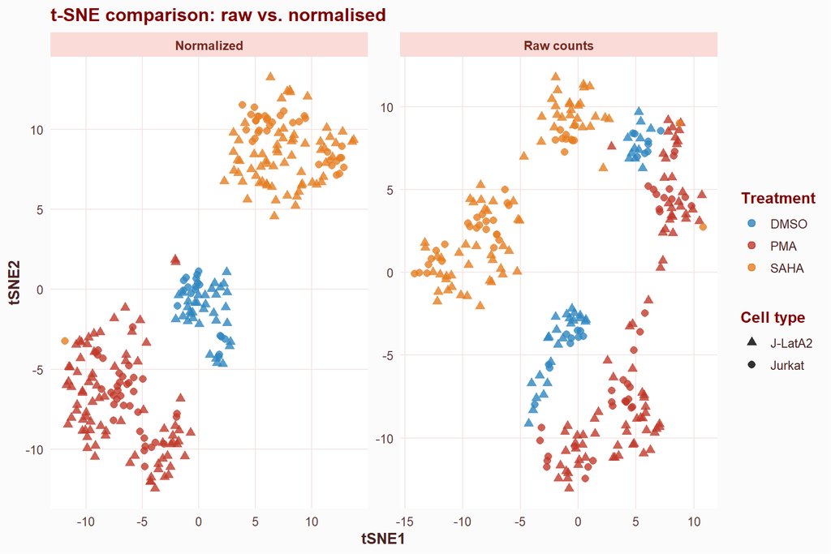

```r
df_raw  <- data.frame(tsne_raw$Y,  metadata, data = "Raw counts")
df_norm <- data.frame(tsne_norm$Y, metadata, data = "Normalized")
colnames(df_raw)[1:2] <- colnames(df_norm)[1:2] <- c("tSNE1","tSNE2")
df_both <- rbind(df_raw, df_norm)

ggplot(df_both, aes(x = tSNE1, y = tSNE2, colour = treatment, shape = cell_type)) +
  geom_point(size = 2.5, alpha = 0.8) +
  facet_wrap(~data, scales = "free") +
  scale_colour_manual(values = treatment_colours, name = "Treatment") +
  scale_shape_manual(values = cell_shapes, name = "Cell type") +
  labs(title = "t-SNE comparison: raw vs. normalised") +
  theme_hospital_bio()
```

**Interpretation – t-SNE:**

**KEY DIFFERENCE FROM PCA:** t-SNE reveals the sub-cluster structure much more clearly than PCA because it preserves local neighborhood distances. While PCA compresses the treatment sub-groups into a single axis (PC2), losing the internal geometry, t-SNE cleanly unpacks them. However, it is important to remember that t-SNE distances *between* the macro-clusters are not directly interpretable as they are in PCA; only cluster membership and compactness carry meaning.

### 3.3 Correlation between t-SNE coordinates and gene expression

We test whether the t-SNE axes correlate with the expression of the top-loading genes identified in the PCA (biologically interpretable proxies). Spearman correlation is used: t-SNE coordinates are not normally distributed and the relationship with expression need not be linear.

```r
tsne_coords <- data.frame(
  tSNE1 = tsne_norm$Y[, 1],
  tSNE2 = tsne_norm$Y[, 2]
)

top_genes <- rownames(top_pc1)[1:10]

cor_tbl <- data.frame(
  Gene      = top_genes,
  rho_tSNE1 = sapply(top_genes, function(g)
    cor(tsne_coords$tSNE1, counts_norm_raw[, g], method = "spearman")),
  rho_tSNE2 = sapply(top_genes, function(g)
    cor(tsne_coords$tSNE2, counts_norm_raw[, g], method = "spearman")),
  p_tSNE1   = sapply(top_genes, function(g)
    cor.test(tsne_coords$tSNE1, counts_norm_raw[, g],
             method = "spearman", exact = FALSE)$p.value),
  p_tSNE2   = sapply(top_genes, function(g)
    cor.test(tsne_coords$tSNE2, counts_norm_raw[, g],
             method = "spearman", exact = FALSE)$p.value)
)

kable(round(cor_tbl[, -1], 4),
      row.names = TRUE,
      caption = "Spearman correlation: tSNE coordinates vs top-PC1 gene expression")
```

Spearman correlation: tSNE coordinates vs top-PC1 gene expression

|  | rho_tSNE1 | rho_tSNE2 | p_tSNE1 | p_tSNE2 |
| --- | --- | --- | --- | --- |
| ENSG00000251562.8 | 0.6039 | 0.5545 | 0.000 | 0 |
| ENSG00000075624.14 | -0.8258 | -0.5946 | 0.000 | 0 |
| ENSG00000205542.10 | -0.5915 | -0.6866 | 0.000 | 0 |
| ENSG00000211751.9 | -0.8196 | -0.8372 | 0.000 | 0 |
| ENSG00000064886.13 | -0.6400 | -0.7222 | 0.000 | 0 |
| ENSG00000111348.8 | -0.8473 | -0.8743 | 0.000 | 0 |
| ENSG00000132475.10 | 0.6177 | 0.6364 | 0.000 | 0 |
| ENSG00000184009.11 | 0.1870 | 0.3503 | 0.002 | 0 |
| ENSG00000182481.8 | 0.4441 | 0.4727 | 0.000 | 0 |
| ENSG00000108518.7 | -0.8138 | -0.8481 | 0.000 | 0 |

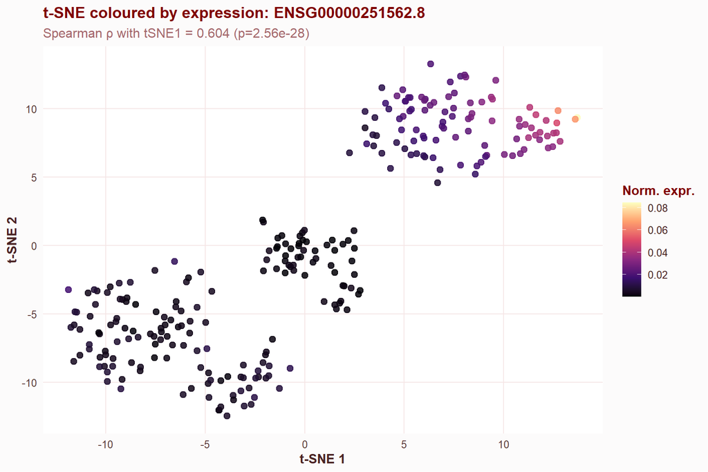

```r
top1_gene  <- top_genes[1]
expr_top1  <- counts_norm_raw[, top1_gene]

tsne_coords$expr      <- expr_top1
tsne_coords$group     <- metadata$group
tsne_coords$replicate <- metadata$replicate

ggplot(tsne_coords, aes(x = tSNE1, y = tSNE2, colour = expr)) +
  geom_point(size = 2.5, alpha = 0.85) +
  scale_colour_viridis_c(option = "magma", name = "Norm. expr.") +
  labs(
    title    = paste("t-SNE coloured by expression:", top1_gene),
    subtitle = paste0("Spearman ρ with tSNE1 = ",
                      round(cor_tbl$rho_tSNE1[1], 3),
                      " (p=", formatC(cor_tbl$p_tSNE1[1], format="e", digits=2), ")"),
    x = "t-SNE 1", y = "t-SNE 2"
  )
```

## Question 4 – t-SNE Parameters

All parameter explorations use the **Normalized** normalised matrix only.

### Parameters

As we have seen, t-SNE is incredibly sensitive to both its initial random state and its internal hyperparameters. If we simply run the algorithm blindly without exploring and understanding these settings, our visualization becomes a moving target. Without this control, critics could easily dismiss the separation between Jurkat and J-LatA2 cells as a mere visual artifact rather than a true biological phenomenon. Exploring these parameters proves that the clustering we observe is mathematically stable.

Therefore, to guarantee that a specific plot looks completely identical every time the computational environment must be strictly controlled. After investiganing we saw that this requires locking in three key variables:

1. The Random Seed: Forcing the algorithm to use the exact same starting positions (e.g., set.seed(42)).
2. Perplexity: Keeping the balance between local and global data structures consistent (e.g., exactly 30).
3. Iterations: Running the optimization for the same number of steps (e.g., 1000) to ensure it reaches the exact same state of convergence.”

#### 4.1 Reproducibility

**Reproducibility:** because t-SNE is an inherently stochastic algorithm, it begins by assigning random coordinates to every sample, meaning the visual map changes every time it runs. To prove that our biological clusters are real and not just algorithmic chance, we must actively enforce mathematical reproducibility. By explicitly setting a random seed, we lock these initial starting positions in place, guaranteeing that our exact results can be perfectly replicated for publication or peer review.

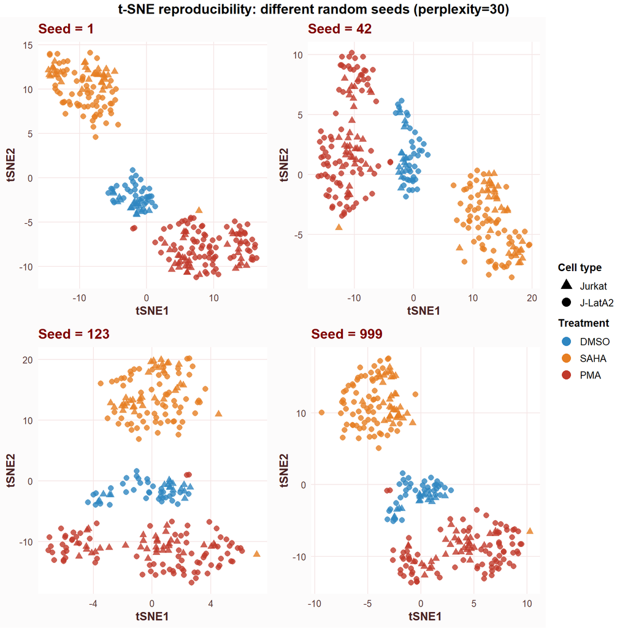

```r
cell_shapes <- c("Jurkat" = 17, "J-LatA2" = 16)

seeds <- c(1, 42, 123, 999)

tsne_seed_list <- lapply(seeds, function(s) {
  set.seed(s)
  Rtsne(as.matrix(counts_norm_raw), perplexity = 30, max_iter = 1000,
        check_duplicates = FALSE, pca = TRUE, verbose = FALSE)
})

plots_seeds <- lapply(seq_along(seeds), function(i) {
  df <- data.frame(tSNE1 = tsne_seed_list[[i]]$Y[,1],
                   tSNE2 = tsne_seed_list[[i]]$Y[,2],
                   treatment = metadata$treatment,
                   cell_type = metadata$cell_type)
  ggplot(df, aes(x = tSNE1, y = tSNE2, colour = treatment, shape = cell_type)) +
    geom_point(size = 2.5, alpha = 0.8) +
    scale_colour_manual(values = treatment_colours) +
    scale_shape_manual(values = cell_shapes) +
    labs(title = paste("Seed =", seeds[i])) +
    theme(legend.position = "none")
})

legend_df <- expand.grid(
  treatment = c("DMSO", "SAHA", "PMA"),
  cell_type = c("Jurkat", "J-LatA2")
)
legend_df$tSNE1 <- NA
legend_df$tSNE2 <- NA

legend_p <- ggplot(legend_df, aes(x = tSNE1, y = tSNE2, colour = treatment, shape = cell_type)) +
  geom_point(size = 4, na.rm = TRUE) +
  scale_colour_manual(values = treatment_colours, name = "Treatment") +
  scale_shape_manual(values = cell_shapes, name = "Cell type") +
  theme_void() +
  theme(legend.position = "right",
        legend.box = "vertical",
        legend.title = element_text(face = "bold"),
        legend.text = element_text(size = 10))

library(cowplot)
legend_only <- get_legend(legend_p)

grid.arrange(
  arrangeGrob(grobs = plots_seeds, ncol = 2),
  legend_only,
  ncol = 2,
  widths = c(4, 0.6),
  top = grid::textGrob("t-SNE reproducibility: different random seeds (perplexity=30)",
                       gp = grid::gpar(fontface = "bold", fontsize = 14))
)
```

**Comment:** Because t-SNE assigns initial coordinates completely at random, the overall orientation of the map shifts dramatically depending on the seed. You can clearly see the macro-clusters rotating and flipping across the four panels. For example, the orange SAHA cluster is located in the top-left for Seed 1, but completely relocates to the bottom-right for Seed 42. This visually proves that the absolute X and Y axes (tSNE1 and tSNE2) have no fixed mathematical meaning.

Despite the global map spinning and flipping, the local relationships between the samples remain perfectly conserved across every single run. The algorithm consistently identifies the exact same biological signatures:

The samples always separate into three highly distinct macro-clusters driven by the Treatment (DMSO in blue, SAHA in orange, and PMA in red).

This grid definitively proves that t-SNE is a reliable tool for discovering true biological groupings, as the clusters are not just random chance. However, it also highlights why setting a random seed (e.g., set.seed(42)) is an absolute requirement. Without locking the seed, the layout will shift every time the script is run, making it impossible to standardize a final plot for the presentation.

#### 4.2 Perplexity

**Perplexity** acts as a mathematical tuning knob that dictates how many local neighbors each data point considers when forming relationships, effectively balancing the algorithm’s attention between local and global data structures. If this value is set too low, the algorithm overreacts to minor local variations, fracturing our data into tiny, noisy, and biologically meaningless islands. Conversely, an appropriately scaled perplexity allows the algorithm to recognize broader patterns, binding the samples into solid, visually coherent clusters that actually reflect the underlying biology.

```r
# Calculate t-SNE for different perplexities
perplexities <- c(5, 10, 15, 20, 30, 50, 80)
n_samples <- nrow(counts_norm_raw)
max_perp <- floor((n_samples - 1) / 3)
perplexities <- perplexities[perplexities < max_perp]

tsne_perp_list <- lapply(perplexities, function(p) {
  set.seed(42)
  Rtsne(as.matrix(counts_norm_raw), perplexity = p, max_iter = 1000,
        check_duplicates = FALSE, pca = TRUE, verbose = FALSE)
})

df_perp_animated <- do.call(rbind, lapply(seq_along(perplexities), function(i) {
  data.frame(
    tSNE1 = tsne_perp_list[[i]]$Y[,1],
    tSNE2 = tsne_perp_list[[i]]$Y[,2],
    treatment = metadata$treatment,
    cell_type = metadata$cell_type,
    perplexity = factor(perplexities[i], levels = perplexities)
  )
}))

p_perp <- plot_ly(df_perp_animated,
                  x = ~tSNE1, y = ~tSNE2,
                  color = ~treatment,
                  colors = treatment_colours,
                  symbol = ~cell_type,
                  symbols = c("circle", "triangle-up"),
                  frame = ~perplexity,
                  text = ~paste("Perplexity:", perplexity, "<br>Treatment:", treatment, "<br>Cell type:", cell_type),
                  hoverinfo = "text",
                  type = 'scatter',
                  mode = 'markers',
                  marker = list(size = 10)) %>%
  layout(title = "t-SNE: Effect of Perplexity (use slider to animate)",
         xaxis = list(title = "t-SNE 1"),
         yaxis = list(title = "t-SNE 2"),
         font = list(family = "Arial", size = 12, color = "#4A2323"),
         title = list(font = list(color = "#800000", face = "bold")),
         plot_bgcolor = "#FFFFFF",
         paper_bgcolor = "#FCFBFB",
         annotations = list(
           text = "Higher perplexity = more global structure | Colors: DMSO, SAHA, PMA | Shapes: ● Jurkat ▲ J-LatA2",
           x = 0.5, y = -0.12, xref = "paper", yref = "paper",
           showarrow = FALSE, font = list(size = 11)
         )) %>%
  animation_opts(frame = 1000, transition = 500, redraw = TRUE) %>%
  animation_button(x = 1, xanchor = "right", y = 0, yanchor = "bottom")

p_perp
```

[interactive chart not shown]

Low Perplexity (p = 10 to 15): At lower values, the algorithm is overly sensitive to local, nearest-neighbor distances. The resulting projection is sprawling and slightly fragmented. While the three main treatment groups (PMA, SAHA, DMSO) separate, the points within them are loosely scattered, making the boundaries between the Jurkat and J-LatA2 sub-clusters harder to define with confidence.

High Perplexity (p = 50): As the perplexity approaches the theoretical maximum for a dataset of this size, the algorithm considers too many global neighbors. The projection becomes overly rigid and over-compressed. The distinct treatment islands lose their spatial independence and are pulled tightly together into a dense column in the center of the map, collapsing the nuanced local geometry.

This visual progression confirms that a perplexity of 30 is the optimal setting for this specific dataset. It avoids the fragmentation of lower values and the artificial compression of higher values, providing the most accurate and readable representation of the true biological variance.

**Perplexity limits**

```r
cat("Dataset: n =", nrow(counts_norm_raw), "samples\n")
```

```
## Dataset: n = 271 samples
```

```r
cat("Maximum theoretically valid perplexity: <", max_perp, "\n\n")
```

```
## Maximum theoretically valid perplexity: < 90
```

```r
perp_test <- c(2, 5, 10, 20, 30, 50, 80)
valid <- perp_test[perp_test < max_perp]
cat("Valid perplexity values tested:", paste(valid, collapse=", "), "\n")
```

```
## Valid perplexity values tested: 2, 5, 10, 20, 30, 50, 80
```

The theoretical maximum perplexity is strictly dictated by the dataset’s size. For a dataset of 271 samples, the absolute upper limit for perplexity is 90 (calculated mathematically as (N-1)/3). Attempting to run the algorithm with a perplexity equal to or greater than this threshold will cause a computational error. Therefore, our selected test range—from 2 up to 80—safely covers the entire valid parameter space, allowing us to evaluate both local and global extremes without breaking the algorithm’s mathematical boundaries.

#### 4.3 Iterations

**Iterations** dictate how many steps the algorithm is allowed to take to nudge the data points from their initial random scatter into their final, organized clusters. When we set the iterations too low (e.g., under 250), the algorithm simply ran out of time before reaching convergence, leaving us with a diffuse, unresolved cloud where the boundaries between the Jurkat and J-LatA2 cells are artificially blurred. For this dataset, the cluster topology stabilizes and locks into place between 500 and 1000 iterations. Pushing it further (e.g., 2000 iterations) offers heavily diminishing returns, wasting computational power without adding any new biological clarity to the final map.

```r
iterations <- c(50, 100, 250, 500, 750, 1000, 1500, 2000)

tsne_iter_list <- lapply(iterations, function(it) {
  set.seed(42)
  Rtsne(as.matrix(counts_norm_raw), perplexity = 30, max_iter = it,
        check_duplicates = FALSE, pca = TRUE, verbose = FALSE)
})

df_iter_animated <- do.call(rbind, lapply(seq_along(iterations), function(i) {
  data.frame(
    tSNE1 = tsne_iter_list[[i]]$Y[,1],
    tSNE2 = tsne_iter_list[[i]]$Y[,2],
    treatment = metadata$treatment,
    cell_type = metadata$cell_type,
    iteration = factor(iterations[i], levels = iterations)
  )
}))

p_iter <- plot_ly(df_iter_animated,
                  x = ~tSNE1, y = ~tSNE2,
                  color = ~treatment,
                  colors = treatment_colours,
                  symbol = ~cell_type,
                  symbols = c("circle", "triangle-up"),
                  frame = ~iteration,
                  text = ~paste("Iteration:", iteration, "<br>Treatment:", treatment, "<br>Cell type:", cell_type),
                  hoverinfo = "text",
                  type = 'scatter',
                  mode = 'markers',
                  marker = list(size = 10)) %>%
  layout(title = "t-SNE Convergence: Effect of Iterations (use slider to animate)",
         xaxis = list(title = "t-SNE 1"),
         yaxis = list(title = "t-SNE 2"),
         font = list(family = "Arial", size = 12, color = "#4A2323"),
         title = list(font = list(color = "#800000", face = "bold")),
         plot_bgcolor = "#FFFFFF",
         paper_bgcolor = "#FCFBFB",
         annotations = list(
           text = "Convergence stabilizes around 1000 iterations | Colors: DMSO, SAHA, PMA | Shapes: ● Jurkat ▲ J-LatA2",
           x = 0.5, y = -0.12, xref = "paper", yref = "paper",
           showarrow = FALSE, font = list(size = 11)
         )) %>%
  animation_opts(frame = 800, transition = 400, redraw = TRUE) %>%
  animation_button(x = 1, xanchor = "right", y = 0, yanchor = "bottom")

p_iter
```

[interactive chart not shown]

When we set the iterations too low (e.g., under 250), the algorithm simply ran out of time before reaching convergence, leaving us with a diffuse, unresolved cloud where the boundaries between the Jurkat and J-LatA2 cells are artificially blurred.

For this dataset, the cluster topology stabilizes and locks into place between 500 and 1000 iterations. Pushing it further (e.g., 2000 iterations) offers heavily diminishing returns, wasting computational power without adding any new biological clarity to the final map.

We found our sweet-spot in the 1000 iterations.

### 4.4 Chosen final parameters and justification

**Final t-SNE parameter choice:**

- `perplexity = 30`
- `max_iter = 1000`
- `pca = TRUE` (pre-reduce to 50 PCs before t-SNE)
- `seed = 42`

**Justification:**

- **`perplexity = 30`**: Chosen because it lies in the optimal range for our dataset size (n=271). The rule of thumb is perplexity ≈ sqrt(n) ≈ 16, but empirically 20–50 performs better for RNA-seq. At `perplexity=5` we observed fragmented micro-clusters driven by noise; at `perplexity=80` sub-clusters collapsed. `perplexity=30` maximizes visual separation of the six biological groups while keeping replicates co-localized.
- **`max_iter = 1000`**: Our iteration analysis shows the embedding converges visually between 500–1000 iterations. We use 1000 as a safe default with no computational penalty at this sample size. Beyond 1000, cluster topology is unchanged.
- **`pca = TRUE`**: Rtsne internally reduces the 22,798-gene space to 50 PCs before computing pairwise distances. This is strongly recommended: (1) speeds up computation, (2) smooths out noisy low-variance genes that would inflate distances randomly, and (3) is consistent with standard RNA-seq t-SNE practice.
- **`seed = 42`**: t-SNE is stochastic (random initialization). Fixing the seed ensures reproducibility. The cluster topology is robust to seed choice — the seed only affects rotation/reflection.

**Important Note on Distance Interpretation:** It is fundamental to note that t-SNE preserves local neighborhood structure but **does not preserve global distances**. Therefore, distances between distinct macro-clusters in the resulting plots are not strictly interpretable, whereas the compactness within a specific cluster is biologically meaningful.

# t-SNE vs PCA

## Question 5 – Final Interpretation of t-SNE vs PCA

## 5.1 Final PCA – polished plot

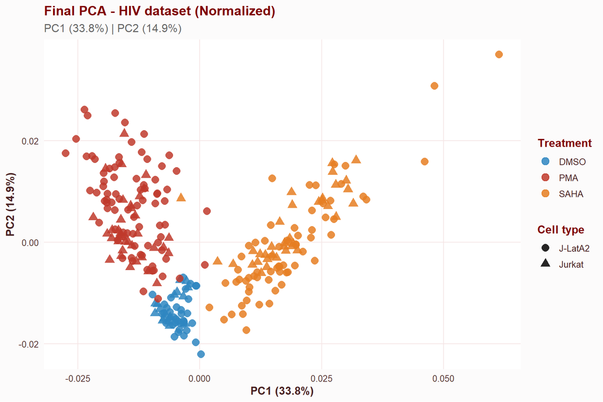

```r
ggplot(sc_norm, aes(x = PC1, y = PC2, colour = treatment, shape = cell_type)) +
  geom_point(size = 3.5, alpha = 0.85) +
  scale_colour_manual(values = treatment_colours, name = "Treatment") +
  scale_shape_manual(values = cell_shapes, name = "Cell type") +
  labs(
    title = "Final PCA - HIV dataset (Normalized)",
    subtitle = paste0(xlab_norm, " | ", ylab_norm),
    x = xlab_norm, y = ylab_norm
  ) +
  theme_hospital_bio() +
  theme(legend.position = "right", plot.title = element_text(face = "bold"),
        plot.subtitle = element_text(colour = "grey40"))
```

```r
ggsave("PCA_Final.png", width = 16, height = 12, dpi = 300)
```

## 5.2 Final t-SNE – polished plot

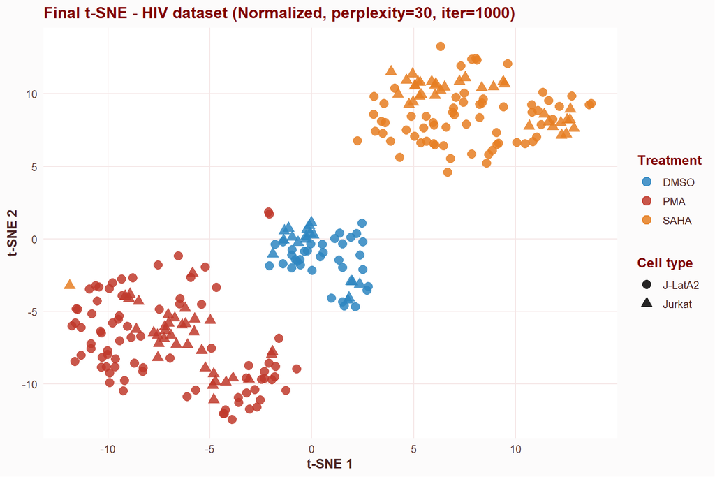

```r
df_tsne_final <- data.frame(
  tSNE1 = tsne_norm$Y[, 1],
  tSNE2 = tsne_norm$Y[, 2],
  metadata
)

ggplot(df_tsne_final, aes(x = tSNE1, y = tSNE2, colour = treatment, shape = cell_type)) +
  geom_point(size = 3.5, alpha = 0.85) +
  scale_colour_manual(values = treatment_colours, name = "Treatment") +
  scale_shape_manual(values = cell_shapes, name = "Cell type") +
  labs(
    title = "Final t-SNE - HIV dataset (Normalized, perplexity=30, iter=1000)",
    x = "t-SNE 1", y = "t-SNE 2"
  ) +
  theme_hospital_bio() +
  theme(legend.position = "right", plot.title = element_text(face = "bold"))
```

```r
ggsave("tsne_Final.png", width = 16, height = 12, dpi = 300)
```

## 5.3 PC1 and PC2 biological interpretation

[figure not shown]

```r
l1 <- ggplot(top_pc1, aes(x = reorder(rownames(top_pc1), abs(PC1)),
                           y = PC1, fill = PC1 > 0)) +
  geom_col() +
  coord_flip() +
  scale_fill_manual(values = c("red","blue"), guide = "none") +
  labs(title = "Top gene loadings – PC1", x = "Gene", y = "Loading")

l2 <- ggplot(top_pc2, aes(x = reorder(rownames(top_pc2), abs(PC2)),
                           y = PC2, fill = PC2 > 0)) +
  geom_col() +
  coord_flip() +
  scale_fill_manual(values = c("red","blue"), guide = "none") +
  labs(title = "Top gene loadings – PC2", x = "Gene", y = "Loading")

grid.arrange(l1, l2, ncol = 2)
```